# Udacity Data Analyst Nanodegree

# P2: Investigate a [Baseball] Dataset

Author: Gianpaolo Impronta

Date: May 9, 2017

## Questions for Investigation

1. How did salary change over the years?
2. Which team has the highest average salary? And the lowest?
3. Which is the most well paid player at any given time?
4. Which statistics have most influence on salaries?

## Dataset

The 2016 version of The Lahman Baseball Database contains complete batting and pitching statistics from 1871 to 2016, plus fielding statistics, standings, team stats, managerial records, post-season data, and more. The Master (player names, DOB, and biographical info), Pitching (regular season pitching statistics), Fielding (regular season fielding statistics), Batting (regular season batting statistics), Salaries (players salaries data) and Teams (yearly stats and standings) tables are required for this balk analysis.

## Data Wrangling

### Missing Data

Since the salaries table contains data from 1985 to 2016, we have to exclude all years before 1985 from our analysis.

### Merging Tables

To obtain correlations between all the baseball statistics we have to merge the master, batting, fielding, pitching, and salaries tables.

## Analysis

### 1. Salary over the years

```python
# Importing modules

%matplotlib inline
import pandas as pd
import numpy as np
import seaborn as sns
import matplotlib.pyplot as plt
```

```python
# Loading csv's into memory

df_master = pd.read_csv('Master.csv')
df_batting = pd.read_csv('Batting.csv')
df_fielding = pd.read_csv('Fielding.csv')
df_pitching = pd.read_csv('Pitching.csv')
df_salaries = pd.read_csv('Salaries.csv')
df_teams = pd.read_csv('Teams.csv')
```

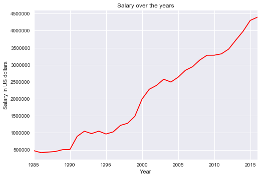

```python
salary_by_year = df_salaries[['salary', 'yearID']].groupby('yearID').mean()
fig = salary_by_year.plot(color='red', legend=False)
fig.set_xlabel('Year')
fig.set_ylabel('Salary in US dollars')
fig.set_title('Salary over the years')
```

Correlation between year and salary:

```python
salary_by_year_corr = df_salaries[['salary', 'yearID']].groupby('yearID', as_index=False).mean().corr().loc['yearID', 'salary']
salary_by_year_corr
```

```
0.98474421278182411
```

### 2. Average salary by team

```python
avg_salary_by_team = df_salaries[['teamID', 'salary']].groupby('teamID', as_index= False).mean()
highest_team = avg_salary_by_team.sort_values('salary',ascending=False).iloc[0,0]
lowest_team = avg_salary_by_team.sort_values('salary',ascending=False).iloc[-1,0]

print('%s is the team with the highest average salary'% highest_team)
print('%s is the team with the lowest average salary'% lowest_team)
```

```
NYY is the team with the highest average salary
ML4 is the team with the lowest average salary
```

### 3. Most well-paid player

```python
player_names = pd.merge(df_salaries[['playerID', 'salary']], df_master[['playerID', 'nameLast', 'nameGiven']], how='inner', on='playerID')
sorted_player_names = player_names.sort_values('salary', ascending= False)[['nameGiven', 'nameLast', 'salary']]
sorted_player_names.head()
```

|  | nameGiven | nameLast | salary |
| --- | --- | --- | --- |
| 23224 | Clayton Edward | Kershaw | 33000000 |
| 12216 | Alexander Enmanuel | Rodriguez | 33000000 |
| 12217 | Alexander Enmanuel | Rodriguez | 33000000 |
| 23223 | Clayton Edward | Kershaw | 32571000 |
| 12218 | Alexander Enmanuel | Rodriguez | 32000000 |

```python
sorted_player_names.iloc[0:2]
```

|  | nameGiven | nameLast | salary |
| --- | --- | --- | --- |
| 23224 | Clayton Edward | Kershaw | 33000000 |
| 12216 | Alexander Enmanuel | Rodriguez | 33000000 |

```python
print('%s %s and %s %s are the most well-paid players of all time' % (sorted_player_names.iloc[0,0], sorted_player_names.iloc[0,1], sorted_player_names.iloc[1,0], sorted_player_names.iloc[1,1]))
```

```
Clayton Edward Kershaw and Alexander Enmanuel Rodriguez are the most well-paid players of all time
```

### 4. Correlations between statistics and salaries

#### Cleaning tables

Since the salaries table only has data from 1985 to 2016 we have to select data from other tables following these parameters.

```python
# selecting data from 1985 to 2016
df_batting = df_batting[df_batting.loc[:,'yearID'] >= 1985]
df_fielding = df_fielding[df_fielding.loc[:,'yearID'] >= 1985]
df_pitching = df_pitching[df_pitching.loc[:,'yearID'] >= 1985]
```

#### Merging Master, Batting, Fielding, Pitching and salaries tables

```python
df_mb = pd.merge(df_master[['playerID', 'weight', 'height', 'bats', 'throws']], df_batting[['yearID', 'playerID', 'G', 'AB', 'R', 'H','2B', '3B', 'HR', 'RBI', 'SB', 'CS', 'BB', 'SO', 'IBB', 'HBP', 'SH','SF', 'GIDP']].groupby(['playerID', 'yearID'], as_index=False).mean(), how='inner', on='playerID')
```

```python
df_mbf = pd.merge(df_mb, df_fielding[['playerID', 'G', 'GS', 'InnOuts', 'PO', 'A', 'E', 'DP', 'PB', 'WP', 'SB', 'CS', 'ZR']].groupby('playerID', as_index=False).mean(), how='inner', on='playerID', suffixes=('_batting', '_fielding'))
```

```python
df_mbfp = pd.merge(df_mbf, df_pitching[['playerID', 'W', 'L', 'G', 'GS', 'CG', 'SHO', 'SV', 'IPouts', 'H', 'ER', 'HR', 'BB', 'SO', 'BAOpp', 'ERA', 'IBB', 'WP', 'HBP', 'BK', 'BFP', 'GF', 'R', 'SH', 'SF', 'GIDP']].groupby('playerID', as_index=False).mean(), how='inner', on='playerID', suffixes=('_batting', '_pitching'))
```

```python
all_dfs = pd.merge(df_mbfp, df_salaries[['playerID', 'salary']].groupby('playerID', as_index=False).mean(), how='inner', on='playerID')
```

```python
def corr_per_group(df, column1, column2, group):
    """
    Return correlations between column1 and column2 grouped by group
    """
    grouped_df = df.groupby(group)
    corr_df = grouped_df[[column1,column2]].corr()
    idx_slice = pd.IndexSlice
    values = corr_df.loc[idx_slice[:,column1], idx_slice[column2]]
    clean_values = values.dropna()
    return clean_values

# list of columns to find correlations
column_list = ['weight', 'height', 'G_batting',
       'AB', 'R_batting', 'H_batting', '2B', '3B', 'HR_batting', 'RBI',
       'SB_batting', 'CS_batting', 'BB_batting', 'SO_batting', 'IBB_batting',
       'HBP_batting', 'SH_batting', 'SF_batting', 'GIDP_batting', 'G_fielding',
       'GS_batting', 'InnOuts', 'PO', 'A', 'E', 'DP', 'PB', 'WP_batting',
       'SB_fielding', 'CS_fielding', 'ZR', 'W', 'L', 'G', 'GS_pitching', 'CG',
       'SHO', 'SV', 'IPouts', 'H_pitching', 'ER', 'HR_pitching', 'BB_pitching',
       'SO_pitching', 'BAOpp', 'ERA', 'IBB_pitching', 'WP_pitching',
       'HBP_pitching', 'BK', 'BFP', 'GF', 'R_pitching', 'SH_pitching',
       'SF_pitching', 'GIDP_pitching']


corr_df = pd.DataFrame() # Dataframe to store correlations

# Correlations between every column in column_list and 'salary' grouped by year
for i in column_list:
    correlation = corr_per_group(all_dfs, i,'salary', 'yearID')
    correlation = pd.DataFrame([correlation[j] for j in list(range(len(correlation)))]
, index = correlation.index.get_level_values(0), columns=[i])
    corr_df = corr_df.join(correlation, how='outer')

# Dropping correlations of 1 and -1 and
corr_df[(corr_df != 1) & (corr_df != -1)].mean().sort_values(ascending=False).head()
```

```
SO_pitching    0.687815
W              0.663042
IPouts         0.611817
BFP            0.597683
SHO            0.570353
dtype: float64
```

At the top of the list we have SO_pitching(Strikeouts while pitching), W(wins) and IPOuts(Outs Pitched) as the three strongest correlations (0.687815, 0.663042, 0.611817 respectively) which makes sense, as the number of wins should lead to a higher salary and so the Strikeouts and Outs Pitched.

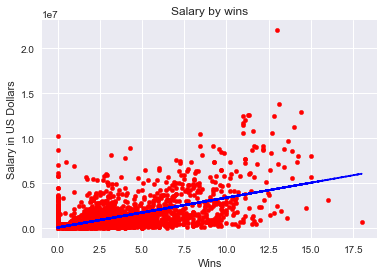

```python
salary_by_wins = all_dfs[['W', 'salary']].drop_duplicates()
fig = salary_by_wins.plot('W', 'salary', kind='scatter', color='red', legend=False)
fig.set_xlabel('Wins')
fig.set_ylabel('Salary in US Dollars')
fig.set_title('Salary by wins')
x = salary_by_wins['W']
y = salary_by_wins['salary']
z = np.polyfit(x, y, 1)
p = np.poly1d(z)
plt.plot(x,p(x),"r--", color='blue')
```

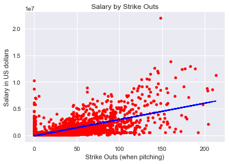

```python
salary_by_SO_pitching = all_dfs[['SO_pitching', 'salary']].drop_duplicates()
fig = salary_by_SO_pitching.plot('SO_pitching', 'salary', 'scatter', color='red', legend=False)
fig.set_xlabel('Strike Outs (when pitching)')
fig.set_ylabel('Salary in US dollars')
fig.set_title('Salary by Strike Outs')
x = salary_by_SO_pitching['SO_pitching']
y = salary_by_SO_pitching['salary']
z = np.polyfit(x, y, 1)
p = np.poly1d(z)
plt.plot(x,p(x),"r--", color='blue')
```

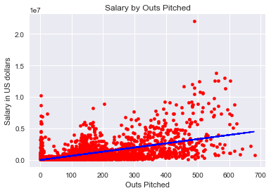

```python
salary_by_IPouts = all_dfs[['IPouts', 'salary']].drop_duplicates()
fig = salary_by_IPouts.plot('IPouts', 'salary', 'scatter', color='red', legend=False)
fig.set_xlabel('Outs Pitched')
fig.set_ylabel('Salary in US dollars')
fig.set_title('Salary by Outs Pitched')
x = salary_by_IPouts['IPouts']
y = salary_by_IPouts['salary']
z = np.polyfit(x, y, 1)
p = np.poly1d(z)
plt.plot(x,p(x),"r--", color='blue')
```

## Conclusions

### Answers

1. How did salary change over the years?
   - Salary has increased over the years.
2. Which team has the highest average salary? And the lowest?
   - NYY is the team with the highest average salary
   - ML4 is the team with the lowest average salary
3. Which is the most well paid player at any given time?
   - Clayton Edward Kershaw and Alexander Enmanuel Rodriguez are the most well-paid players of all time
4. Which statistics have most influence on salaries?
   - SO_pitching(Strikeouts while pitching), W(wins) and IPOuts(Outs Pitched) have the three strongest correlations (0.687815, 0.663042, 0.611817 respectively).

### Limitations

**Empirically observed covariation is a necessary but not sufficient condition for causality.** e.g.: http://www.tylervigen.com/spurious-correlations

Since the salaries table does not have data before 1985, we couldn't analyze how salary would behave at that period of time.

As we could see salaries increased over the years, which could be an effect of inflation, since we didn't have access to these data this is out of scope of the analysis.

This is just a thery based on observations with no statistical value. No statistical tests have been applied, so observations could be caused by coincidence.